## Predicting Portugal white wine quality

by Kittipong Wongwipasamitkun, Nicole Tu, Sho Inagaki 2023/11/19

```python
import numpy as np
import pandas as pd
import requests
import zipfile
import altair as alt
from sklearn import set_config
from sklearn.model_selection import train_test_split
from sklearn.preprocessing import PolynomialFeatures, StandardScaler
from sklearn.compose import make_column_transformer, make_column_selector
from sklearn.pipeline import make_pipeline
from sklearn.model_selection import GridSearchCV
from sklearn.model_selection import RandomizedSearchCV
from sklearn.metrics import fbeta_score, make_scorer
import matplotlib.pyplot as plt
import seaborn as sns
from sklearn.impute import SimpleImputer
from sklearn.linear_model import Ridge
from sklearn.metrics import mean_squared_error
from scipy.stats import uniform
import warnings
warnings.filterwarnings("ignore", category=FutureWarning)
```

# Summary

We tried to make the classification model using the Polynomial Regression with Ridge Regularization algorithm with Randomized Search Hyperparameters which can predict Portugal white wine quality rating (on scale 0-10) through the physicochemical properties of the test wine. The model has trained on the Portugal white wine data set with 4898 observations. In the conclusion, the model performance is not quite good enough both on training data and on an unseen test data set with the test score at around 0.32 with the average train $R^2$ at 0.35 and the average test $R^2$ at 0.27 also with high root MSE and MSE (Mean Squared Error).

The reason we suspect the model cannot predict well is that the wine quality can be judge widely and vary depends on each individual preference taste. Moreover, there is no standard on the taste, for example, high or low in acidity or alcohol level or sulfur level cannot indicate the wine is in good quality or not (It can be both ways!!). As such, we believe this model is at, or close to, the starter required for studying further and could run more collected data to analyze the combination of physicochemical properties which will announce quality of the wine, although more researches need to improve the model performance and understand the characteristics of incorrectly predicted pattern would be in need to investigate further.

# Introduction

Referring to WSET (the Wine & Spirits Education Trust), Wine tasting notes can be described by Systematic Approach to Tasting (SAT) (https://www.wsetglobal.com/media/13271/wset_l4wines_sat_en_aug2023.pdf) , which is consisted of

1. Appearance (colour, clarity, intensity, and other observations)
2. Nose (condition, intensity, aroma characteristics, aroma development)
3. Palate (sweetness, acidity, tannin, alcohol, body, flavour intensity, flavour characteristics, finish, and other observations)
4. Conclusion (quality, readiness for drinking and potential for ageing).

The wine quality which is in the conclusion part, consists mainly on Balance, Length, Intensity and Complexity (BLIC). The result of these qualities, all came from the chemical components in the wine. Subsequently, nowadays, the quality of wine can be determined roughly from the physicochemical components of the wine.

As the physicochemical properties have been related to the wine quality, so we aim to create a machine learning algorithm to predict the quality of wine from the measurement of physicochemical values. Answering this question can help both customers and winemakers to screen or adjust or make decision to the prior wine quality rating derived from the model according to its physicochemical values.

This machine learning algorithm will aim to study only the Portugal white wine to reduce biased from the types of wine and the origin sources of wine as the start point to assess the quality of wine via its physicochemical features.

# Methods

## Data

This data set used in this project is related to white vinho verde wine samples from the north of Portugal created By P. Cortez, A. Cerdeira, Fernando Almeida, Telmo Matos, J. Reis. 2009. The dataset was sourced from website for downloading these datasets is the UC Irvine Machine Learning Repository (https://archive.ics.uci.edu/dataset/186/wine+quality). In addition, these datasets stored the physicochemical properties data on wines and the quality rating to compare and make the quality prediction model.

## Analysis

As we have many variables to concern and most of them have correlation to the target quality, which it is best to not drop these correlated features. Also in the real world with multiple explanatory variables, it is less likely for model to have a linear pattern, and we believe that polynomial regression can be a more realistic model to predict wine quality. The reason we use polynomial regression rather than a linear regression is that it allows us to capture more complex relationships between the predictors and the target variable. By introducing polynomial terms, we can account for non-linear patterns that might exist in the data, enabling the model to better fit the intricacies of wine quality prediction. Moreover, polynomial regression provides greater flexibility, allowing us to uncover potential curvilinear associations between features and the quality of wine, which a linear regression might overlook. This approach enhances our ability to create a more nuanced and accurate predictive model for wine quality assessment. Therefore, we choose the **Polynomial regression with ridge regularization** to reduce the effect of multicolinearity, and use **Random search** to optimize the hyperparameters. Data was partitioned by 70% for the training set and 30% for the test set. All variables were standardized just prior to model fitting. The Python programming language (Van Rossum and Drake 2009) and the following Python packages were used to perform the analysis: numpy(Harris et al. 2020), Pandas (McKinney 2010), altair (VanderPlas, 2018), scikit-learn (Pedregosa et al. 2011). The code used to perform the analysis and create this report can be found here: https://github.com/UBC-MDS/DSCI_522_group16/tree/main/src/portugal_wine_quality_predictor.ipynb

# Discussion

We tried to find out whether each of the physicochemical properties might be useful to predict the wine quality rating. We examined the data set that it doesn't have Null value or any adjustment needed for any values. After that we make a correlation matrix for all the variables in this data set to recognize the pattern or choose to drop some variable out.

```python
# download data as zip and extract

# If you want to download file from url then uncomment below

# url = "https://archive.ics.uci.edu/dataset/186/wine+quality/wine+quality.zip"
# request = requests.get(url)
# with open("../data/raw/wine+quality.zip", 'wb') as f:
#     f.write(request.content)

# with zipfile.ZipFile("../data/raw/wine+quality.zip", 'r') as zip_ref:
#     zip_ref.extractall("../data/raw")
```

```python
# pre-process data (e.g., drop na, check data info)
# read white wine data
white_wine = pd.read_csv('../data/Raw/winequality-white.csv', sep=';')
white_wine.dropna(inplace=True)
white_wine.info()
```

```
<class 'pandas.core.frame.DataFrame'>
RangeIndex: 4898 entries, 0 to 4897
Data columns (total 12 columns):
 #   Column                Non-Null Count  Dtype
---  ------                --------------  -----
 0   fixed acidity         4898 non-null   float64
 1   volatile acidity      4898 non-null   float64
 2   citric acid           4898 non-null   float64
 3   residual sugar        4898 non-null   float64
 4   chlorides             4898 non-null   float64
 5   free sulfur dioxide   4898 non-null   float64
 6   total sulfur dioxide  4898 non-null   float64
 7   density               4898 non-null   float64
 8   pH                    4898 non-null   float64
 9   sulphates             4898 non-null   float64
 10  alcohol               4898 non-null   float64
 11  quality               4898 non-null   int64
dtypes: float64(11), int64(1)
memory usage: 459.3 KB
```

```python
np.random.seed(522)
# 1. split train and test data as df, save to folder.
white_train, white_test = train_test_split(white_wine, train_size=0.70, random_state=123)
white_train.to_csv("../data/Processed/white_train.csv")
white_test.to_csv("../data/Processed/white_test.csv")
```

```python
# 2. EDA by visualization

white_train.head()

# Visualize correlation
white_train.corr().style.background_gradient()
```

|  | fixed acidity | volatile acidity | citric acid | residual sugar | chlorides | free sulfur dioxide | total sulfur dioxide | density | pH | sulphates | alcohol | quality |
| --- | --- | --- | --- | --- | --- | --- | --- | --- | --- | --- | --- | --- |
| fixed acidity | 1.000000 | -0.022159 | 0.283248 | 0.098448 | 0.017915 | -0.051813 | 0.090352 | 0.269401 | -0.423450 | -0.024174 | -0.125424 | -0.118615 |
| volatile acidity | -0.022159 | 1.000000 | -0.147688 | 0.064137 | 0.076459 | -0.088009 | 0.085720 | 0.029973 | -0.029339 | -0.050048 | 0.062962 | -0.195553 |
| citric acid | 0.283248 | -0.147688 | 1.000000 | 0.107066 | 0.127680 | 0.092379 | 0.118290 | 0.160669 | -0.178773 | 0.064732 | -0.093406 | -0.018860 |
| residual sugar | 0.098448 | 0.064137 | 0.107066 | 1.000000 | 0.076111 | 0.280611 | 0.396009 | 0.843845 | -0.198103 | -0.029428 | -0.457366 | -0.085984 |
| chlorides | 0.017915 | 0.076459 | 0.127680 | 0.076111 | 1.000000 | 0.099581 | 0.192030 | 0.241153 | -0.097633 | 0.016289 | -0.349867 | -0.200642 |
| free sulfur dioxide | -0.051813 | -0.088009 | 0.092379 | 0.280611 | 0.099581 | 1.000000 | 0.620482 | 0.282654 | 0.021046 | 0.067162 | -0.244811 | 0.008141 |
| total sulfur dioxide | 0.090352 | 0.085720 | 0.118290 | 0.396009 | 0.192030 | 0.620482 | 1.000000 | 0.526727 | 0.014098 | 0.135311 | -0.456719 | -0.175026 |
| density | 0.269401 | 0.029973 | 0.160669 | 0.843845 | 0.241153 | 0.282654 | 0.526727 | 1.000000 | -0.096938 | 0.071511 | -0.776427 | -0.292935 |
| pH | -0.423450 | -0.029339 | -0.178773 | -0.198103 | -0.097633 | 0.021046 | 0.014098 | -0.096938 | 1.000000 | 0.170854 | 0.123852 | 0.098827 |
| sulphates | -0.024174 | -0.050048 | 0.064732 | -0.029428 | 0.016289 | 0.067162 | 0.135311 | 0.071511 | 0.170854 | 1.000000 | -0.014943 | 0.070664 |
| alcohol | -0.125424 | 0.062962 | -0.093406 | -0.457366 | -0.349867 | -0.244811 | -0.456719 | -0.776427 | 0.123852 | -0.014943 | 1.000000 | 0.428870 |
| quality | -0.118615 | -0.195553 | -0.018860 | -0.085984 | -0.200642 | 0.008141 | -0.175026 | -0.292935 | 0.098827 | 0.070664 | 0.428870 | 1.000000 |

Figure 1. Correlation matrix indicating potential multicolinarity among features.

From figure 1, it turns out that among explanatory features, density and residual sugar are highly correlated (0.844); density and total sulfur dioxide are highly correlated(0.527); total sulfur dioxide and free sulfur dioxide are highly correlated (0.620).

Since the free SO2 is the active, unbound form that contributes to antioxidant and antimicrobial properties, and the Total SO2 includes both free and bound forms, providing an overall measure of sulfur dioxide content in the win, we drop the free sulfur dioxide from the data. .

```python
# drop redundant feature
white_train = white_train.drop(columns=["free sulfur dioxide"])
```

Let's examine the relationship between the three highly correlated features with target variable by scatter plot matrix, figure 2, as shown below:

```python
alt.data_transformers.enable('vegafusion')  # simplify working with large datasets

alt.Chart(white_train).mark_point(opacity=0.3, size=10).encode(
     alt.X(alt.repeat('row'), type='quantitative'),         #encodes the x-axis and y-axis as quantitative values. The 'repeat' function is used to specify that the x-axis should repeat for each row and the y-axis should repeat for each column.
     alt.Y(alt.repeat('column'), type='quantitative')
).properties(
    width=100,
    height=100
).repeat(
    column=['density', 'residual sugar', 'total sulfur dioxide', 'quality'],
    row=['density', 'residual sugar', 'total sulfur dioxide','quality'])
```

[interactive chart not shown]

Figure 2. Scatter Plot Matrix indicating correlation between three highly correlated features with target variable

From figure 2, since both residual sugar, density, and total sulfur dioxide have correlation with the target quality, it is not a good idea to drop these correlated features. Instead, we pick the **polynomial regression with ridge regularization** to reduce multicolinearity, and use **Random search** to optimize the hyperparamters.

The reason we use polynomial regression rather than a linear regression is that in the real world scenario with multiple explanatory variables, it is less likely for model to have a linear pattern, and we believe that polynomial regression can be a more realistic model to predict wine quality.

Now lets examine the distribution of the features to decide how to preprocess them:

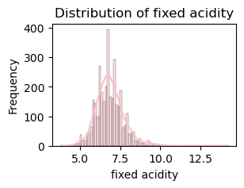

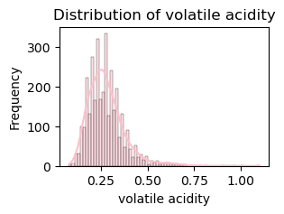

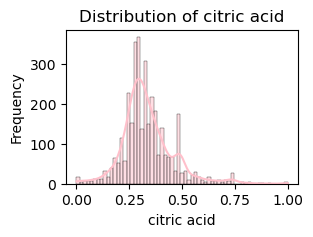

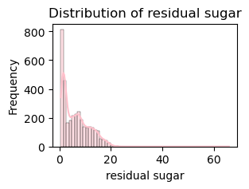

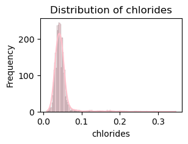

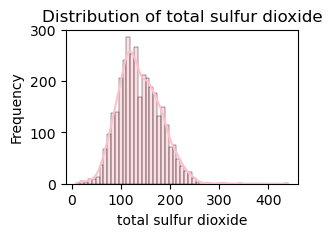

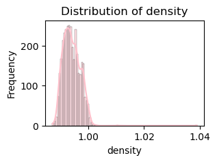

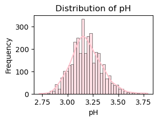

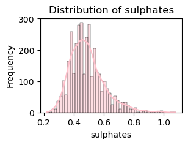

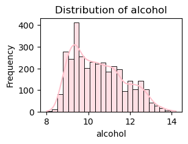

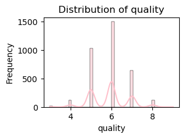

```python
# Create a histogram for each column
for column in white_train.columns:
    plt.figure(figsize=(3, 2))
    sns.histplot(white_train[column], kde=True, color='pink')
    plt.title(f'Distribution of {column}')
    plt.xlabel(column)
    plt.ylabel('Frequency')
    plt.show()
```

Figure 3. Distribution of features in training set.

```python
x_train_w, y_train_w = white_train.drop(columns=["quality"]), white_train["quality"]
x_test_w, y_test_w = white_test.drop(columns=["quality"]), white_test["quality"]
```

```python
# Polinomial regression
numeric_transformer = make_pipeline(SimpleImputer(strategy="median"), StandardScaler())
numeric_feats = x_train_w.columns.tolist()

# Create a ColumnTransformer
ct = make_column_transformer(
    (numeric_transformer, numeric_feats),  # Apply numeric transformer to numeric_feats
    (PolynomialFeatures(), numeric_feats) # Apply poly_transformer to numeric_feats
  )

Pipe_poly=make_pipeline(ct, Ridge())
```

```python
# Hyperparameter Tuning by Random Search
param_dist = { #can pass either a distribution or list of values for random search
    "columntransformer__polynomialfeatures__degree":list(range(1, 8)),
    "ridge__alpha": np.logspace(-2, 2, 15)}

random_search = RandomizedSearchCV(Pipe_poly, param_distributions = param_dist, n_iter=15,
n_jobs=-1, return_train_score=True)
```

```python
# fit the random search with training data
random_search.fit(x_train_w, y_train_w)
```

```
RandomizedSearchCV(estimator=Pipeline(steps=[('columntransformer',
                                              ColumnTransformer(transformers=[('pipeline',
                                                                               Pipeline(steps=[('simpleimputer',
                                                                                                SimpleImputer(strategy='median')),
                                                                                               ('standardscaler',
                                                                                                StandardScaler())]),
                                                                               ['fixed '
                                                                                'acidity',
                                                                                'volatile '
                                                                                'acidity',
                                                                                'citric '
                                                                                'acid',
                                                                                'residual '
                                                                                'sugar',
                                                                                'chlorides',
                                                                                'total '
                                                                                'sulfur '
                                                                                'dioxide',
                                                                                'density',
                                                                                'pH',
                                                                                'sulphates',...
                   param_distributions={'columntransformer__polynomialfeatures__degree': [1,
                                                                                          2,
                                                                                          3,
                                                                                          4,
                                                                                          5,
                                                                                          6,
                                                                                          7],
                                        'ridge__alpha': array([1.00000000e-02, 1.93069773e-02, 3.72759372e-02, 7.19685673e-02,
       1.38949549e-01, 2.68269580e-01, 5.17947468e-01, 1.00000000e+00,
       1.93069773e+00, 3.72759372e+00, 7.19685673e+00, 1.38949549e+01,
       2.68269580e+01, 5.17947468e+01, 1.00000000e+02])},
                   return_train_score=True)
```

```python
random_search.best_params_
```

```
{'ridge__alpha': 0.13894954943731375,
 'columntransformer__polynomialfeatures__degree': 2}
```

From above, we got best hyperparameters from random search, which are ridge alpha around 0.13895 and the polynomial degree of 2

```python
best_model = random_search.best_estimator_ # Get the best model based on optimization
```

```python
# Model Evaluation
from sklearn.metrics import mean_squared_error, r2_score
from sklearn.model_selection import cross_validate

scoring = {
    "r2": "r2",
    "sklearn MAPE": "neg_mean_absolute_percentage_error",
    "neg_root_mean_square_error": "neg_root_mean_squared_error",
    "neg_mean_squared_error": "neg_mean_squared_error"}

score_table=pd.DataFrame(cross_validate(best_model, x_train_w, y_train_w, return_train_score=True, scoring=scoring)).T
score_table
```

|  | 0 | 1 | 2 | 3 | 4 |
| --- | --- | --- | --- | --- | --- |
| fit_time | 0.037892 | 0.030191 | 0.015626 | 0.031333 | 0.022867 |
| score_time | 0.011269 | 0.008135 | 0.015649 | 0.015640 | 0.010105 |
| test_r2 | 0.310275 | 0.352294 | 0.342595 | 0.062560 | 0.286411 |
| train_r2 | 0.357499 | 0.347234 | 0.346548 | 0.354813 | 0.363308 |
| test_sklearn MAPE | -0.097457 | -0.103011 | -0.097762 | -0.106176 | -0.102596 |
| train_sklearn MAPE | -0.099286 | -0.097894 | -0.099527 | -0.098261 | -0.097806 |
| test_neg_root_mean_square_error | -0.722673 | -0.744341 | -0.722322 | -0.860427 | -0.753973 |
| train_neg_root_mean_square_error | -0.721092 | -0.715690 | -0.723061 | -0.718781 | -0.713437 |
| test_neg_mean_squared_error | -0.522256 | -0.554044 | -0.521749 | -0.740335 | -0.568475 |
| train_neg_mean_squared_error | -0.519973 | -0.512212 | -0.522818 | -0.516646 | -0.508992 |

```python
score_table.mean(axis=1).to_frame()
```

|  | 0 |
| --- | --- |
| fit_time | 0.027582 |
| score_time | 0.012159 |
| test_r2 | 0.270827 |
| train_r2 | 0.353880 |
| test_sklearn MAPE | -0.101400 |
| train_sklearn MAPE | -0.098555 |
| test_neg_root_mean_square_error | -0.760747 |
| train_neg_root_mean_square_error | -0.718412 |
| test_neg_mean_squared_error | -0.581372 |
| train_neg_mean_squared_error | -0.516128 |

```python
best_model.score(x_test_w, y_test_w)  # Get the scores using the best hyperparameter values found by grid search
```

```
0.3198310306347695
```